# 001172_HigleyLab_001172_demo_ipynb

## Installing requirements

The cell below installs every Python package needed to run this notebook, at fully pinned versions, using [`uv`](https://github.com/astral-sh/uv) for fast resolution. In Colab the cell is collapsed by default — click the ▶ button to run it.

```python
# install cell skipped during CI (deps preinstalled into system Python)
```

> **⚠️ Restart runtime after install**

> The install may upgrade packages already loaded in the kernel. Go to **Runtime → Restart session**, then **Run all cells below** (skip this install cell on re-run).

# Tutorial for Dual-color mesoscopic imaging of both ACh and calcium across the neocortex of awake mice.

This tutorial shows how to access the data related to [DANDI:001172](https://dandiarchive.org/dandiset/001172/draft) using `pynwb`.

Contents:

- Streaming an NWB file
- Reading an NWB file
- Access Subject and Session metadata
- Access Raw Imaging
- Access Processed Imaging
- Access Processed Behavior
- Access Visual Stimuli
- Access Wheel Signal

```python
import plotly.io as pio
# Render plotly figures inline (works in Colab, Jupyter, and headless
# `nbconvert --execute`/`ipython`-script runners — by default, plotly
# would try to pop a browser window in headless contexts and crash).
pio.renderers.default = "iframe"
```

# Select the subject and session you want to load

```python
subject_id = "grabAM05"
session_id = "11252019-vis-stim"
nwbfile_path = f"sub-{subject_id}/sub-{subject_id}_ses-{session_id}_behavior+image+ophys.nwb"
```

# Streaming an NWB file

This section demonstrates how to access the files on the [DANDI Archive](https://dandiarchive.org) without downloading them. Based on the [Streaming NWB files](https://pynwb.readthedocs.io/en/stable/tutorials/advanced_io/streaming.html) tutorial from [PyNWB](https://pynwb.readthedocs.io/en/stable/#).

The `dandi.dandiapi.DandiAPIClient` can be used to get the S3 URL of the NWB file stored in the DANDI Archive.

```python
from dandi.dandiapi import DandiAPIClient

dandiset_id = "001172"

with DandiAPIClient() as client:
    asset = client.get_dandiset(dandiset_id, 'draft').get_asset_by_path(nwbfile_path)
    s3_url = asset.get_content_url(follow_redirects=1, strip_query=False)
```

We will use `remfile` for streaming the file. You can read more about `remfile` at [this tutorial section](https://pynwb.readthedocs.io/en/stable/tutorials/advanced_io/streaming.html#method-3-remfile).

```python
import h5py
import remfile

file = remfile.File(s3_url)
h5_file = h5py.File(file, "r")
```

# Reading an NWB file

This section demonstrates how to read an NWB file using `pynwb`.

Based on the [NWB File Basics](https://pynwb.readthedocs.io/en/stable/tutorials/general/plot_file.html#sphx-glr-tutorials-general-plot-file-py) tutorial from [PyNWB](https://pynwb.readthedocs.io/en/stable/#).

An NWBFile represents a single session of an experiment. Each NWBFile must have a `session description`, `identifier`, and `session start time`.

Reading is carried out using the NWBHDF5IO class. To read the NWB file use the read mode ("r") to retrieve an NWBFile object.

```python
from pynwb import NWBHDF5IO
io = NWBHDF5IO(file=h5_file, load_namespaces=True)
nwbfile = io.read()
nwbfile
```

root (NWBFile)

session_description: Dual-color mesoscopic imaging of both ACh and calcium across the neocortex of awake mice. All imaging was performed during the second half of the light cycle in awake, behaving mice that were head-fixed so that they could freely run on a cylindrical wheel. Small (20Â° diameter) sinusoidal drifting gratings (2 Hz, 0.04 cycles per degree, 100% contrast) were generated using Psychtoolbox in MATLAB and presented on an LCD monitor at a distance of 20 cm. Stimuli were presented for 1-2 s. Air-puff stimuli were delivered using a thin metal tube aimed at the fur along the back and coupled to a solenoid valve (Clark Solutions) that delivered brief (200-ms) puffs of compressed air.

identifier: 96b5e9cd-a2d2-4c57-865c-2f317d0000e2

**session_start_time**

2019-11-25 13:25:17-05:00

**timestamps_reference_time**

2019-11-25 13:25:17-05:00

**file_create_date**

**0**

2024-08-22 17:32:43.334668+02:00

**experimenter**

('Lohani, Sweyta', 'Moberly, Andrew')

**related_publications**

('https://doi.org/10.1038/s41593-022-01202-6', 'https://github.com/cardin-higley-lab/Lohani_Moberly_et_al_2022')

**acquisition**

**OnePhotonSeriesBlueExcitationGreenChannel (OnePhotonSeries)**

starting_time: 10.0512

rate: 10.000000000000036

resolution: -1.0

comments: no comments

description: Imaging data from Green channel recorded with Blue excitation.

conversion: 1.0

offset: 0.0

unit: n.a.

**data**

HDF5 dataset

| Data type | uint16 |
| --- | --- |
| Shape | (21533, 512, 512) |
| Array size | 10.51 GiB |
| Chunk shape | (19, 512, 512) |
| Compression | gzip |
| Compression opts | 4 |
| Uncompressed size (bytes) | 11289493504 |
| Compressed size (bytes) | 8084707247 |
| Compression ratio | 1.3964010271601612 |

starting_time_unit: seconds

**dimension**

HDF5 dataset

| Data type | int32 |
| --- | --- |
| Shape | (2,) |
| Array size | 8.00 bytes |
| Chunk shape | None |
| Compression | None |
| Compression opts | None |
| Uncompressed size (bytes) | 8 |
| Compressed size (bytes) | 8 |
| Compression ratio | 1.0 |

[512 512]

**imaging_plane (ImagingPlane)**

**optical_channel**

**0 (OpticalChannel)**

description: Green channel of the microscope, 525/50 nm filter.

emission_lambda: 525.0

description: Imaging plane for the Green channel recorded during Blue excitation.

**device (Device)**

description: Camera Type: DUAL_DCAM, Camera Name: C13440-20C S/N: 301751 S/N: 300073

manufacturer: Hamamatsu Inc.

excitation_lambda: 470.0

indicator: ACh3.0

location: Neocortex

conversion: 1.0

unit: meters

origin_coords_unit: meters

grid_spacing_unit: meters

**OnePhotonSeriesGreenExcitationRedChannel (OnePhotonSeries)**

starting_time: 10.11516

rate: 10.000000000000036

resolution: -1.0

comments: no comments

description: Imaging data from Red channel recorded with Green excitation.

conversion: 1.0

offset: 0.0

unit: n.a.

**data**

HDF5 dataset

| Data type | uint16 |
| --- | --- |
| Shape | (21533, 512, 512) |
| Array size | 10.51 GiB |
| Chunk shape | (19, 512, 512) |
| Compression | gzip |
| Compression opts | 4 |
| Uncompressed size (bytes) | 11289493504 |
| Compressed size (bytes) | 8178093603 |
| Compression ratio | 1.3804554034278398 |

starting_time_unit: seconds

**dimension**

HDF5 dataset

| Data type | int32 |
| --- | --- |
| Shape | (2,) |
| Array size | 8.00 bytes |
| Chunk shape | None |
| Compression | None |
| Compression opts | None |
| Uncompressed size (bytes) | 8 |
| Compressed size (bytes) | 8 |
| Compression ratio | 1.0 |

[512 512]

**imaging_plane (ImagingPlane)**

**optical_channel**

**0 (OpticalChannel)**

description: Red channel of the microscope, 630/75 nm filter.

emission_lambda: 630.0

description: Imaging plane for the Red channel recorded during Green excitation.

**device (Device)**

description: Camera Type: DUAL_DCAM, Camera Name: C13440-20C S/N: 301751 S/N: 300073

manufacturer: Hamamatsu Inc.

excitation_lambda: 575.0

indicator: jRCaMP1b

location: Neocortex

conversion: 1.0

unit: meters

origin_coords_unit: meters

grid_spacing_unit: meters

**OnePhotonSeriesVioletExcitationGreenChannel (OnePhotonSeries)**

starting_time: 10.083219999999999

rate: 10.000000000000036

resolution: -1.0

comments: no comments

description: Imaging data from Green channel recorded with Violet excitation.

conversion: 1.0

offset: 0.0

unit: n.a.

**data**

HDF5 dataset

| Data type | uint16 |
| --- | --- |
| Shape | (21533, 512, 512) |
| Array size | 10.51 GiB |
| Chunk shape | (19, 512, 512) |
| Compression | gzip |
| Compression opts | 4 |
| Uncompressed size (bytes) | 11289493504 |
| Compressed size (bytes) | 7950318523 |
| Compression ratio | 1.4200051823508557 |

starting_time_unit: seconds

**dimension**

HDF5 dataset

| Data type | int32 |
| --- | --- |
| Shape | (2,) |
| Array size | 8.00 bytes |
| Chunk shape | None |
| Compression | None |
| Compression opts | None |
| Uncompressed size (bytes) | 8 |
| Compressed size (bytes) | 8 |
| Compression ratio | 1.0 |

[512 512]

**imaging_plane (ImagingPlane)**

**optical_channel**

**0 (OpticalChannel)**

description: Green channel of the microscope, 525/50 nm filter.

emission_lambda: 525.0

description: Imaging plane for the Green channel recorded during Violet excitation.

**device (Device)**

description: Camera Type: DUAL_DCAM, Camera Name: C13440-20C S/N: 301751 S/N: 300073

manufacturer: Hamamatsu Inc.

excitation_lambda: 395.0

indicator: ACh3.0

location: Neocortex

conversion: 1.0

unit: meters

origin_coords_unit: meters

grid_spacing_unit: meters

**Video: 11252019_grabAM05_vis_stim (ImageSeries)**

resolution: -1.0

comments: no comments

description: Video recorded by camera.

conversion: 1.0

offset: 0.0

unit: Frames

**data**

HDF5 dataset

| Data type | uint8 |
| --- | --- |
| Shape | (0, 0, 0) |
| Array size | 0.00 bytes |
| Chunk shape | None |
| Compression | None |
| Compression opts | None |
| Uncompressed size (bytes) | 0 |
| Compressed size (bytes) | 0 |
| Compression ratio | undefined |

[]

**timestamps**

HDF5 dataset

| Data type | float64 |
| --- | --- |
| Shape | (21533,) |
| Array size | 168.23 KiB |
| Chunk shape | (21533,) |
| Compression | gzip |
| Compression opts | 4 |
| Uncompressed size (bytes) | 172264 |
| Compressed size (bytes) | 44824 |
| Compression ratio | 3.8431197572728895 |

timestamps_unit: seconds

interval: 1

**external_file**

HDF5 dataset

| Data type | object |
| --- | --- |
| Shape | (1,) |
| Array size | 8.00 bytes |
| Chunk shape | None |
| Compression | None |
| Compression opts | None |
| Uncompressed size (bytes) | 8 |
| Compressed size (bytes) | 16 |
| Compression ratio | 0.5 |

['sub-grabAM05_ses-11252019-vis-stim_behavior+image+ophys\\3c2c66b8-09cd-43c8-b6b7-70eed92c183a_external_file_0.avi']

**starting_frame**

NumPy array

| Data type | int32 |
| --- | --- |
| Shape | (1,) |
| Array size | 4.00 bytes |

[0]

format: external

**WheelSignal (TimeSeries)**

starting_time: 0.0

rate: 5000.0

resolution: -1.0

comments: no comments

description: The WheelSignal measured over time.

conversion: 0.000152587890625

offset: 0.0

unit: Volts

**data**

HDF5 dataset

| Data type | int16 |
| --- | --- |
| Shape | (10816511,) |
| Array size | 20.63 MiB |
| Chunk shape | (5000000,) |
| Compression | gzip |
| Compression opts | 4 |
| Uncompressed size (bytes) | 21633022 |
| Compressed size (bytes) | 14302692 |
| Compression ratio | 1.5125140078525077 |

starting_time_unit: seconds

**TTLTypesTable (TtlTypesTable)**

description: Contains the type of TTL signals from Spike2 output.

**columns**

**event_name**

Name of each event type.

**event_type_description**

Description of each event type.

**pulse_value**

TTL pulse value for each event type.

**table**

| id | event_name | event_type_description | pulse_value |
| --- | --- | --- | --- |
| 0 | TTLSignalBlueLED | The onset times of the TTLSignalBlueLED event. | 1 |
| 1 | TTLSignalVioletLED | The onset times of the TTLSignalVioletLED event. | 1 |
| 2 | TTLSignalGreenLED | The onset times of the TTLSignalGreenLED event. | 1 |
| 3 | TTLSignalPupilCamera | The onset times of the TTLSignalPupilCamera event. | 1 |

**TTLsTable (TtlsTable)**

description: Contains the TTL signals onset times.

**columns**

**timestamp**

The time that each event occurred, in seconds, from the session start time.

**ttl_type**

The type of TTL that occurred. This is represented as a reference to a row of the TtlTypesTable.

**table**

| id | timestamp | ttl_type |
| --- | --- | --- |
| 0 | 10.0512 | 0 |
| 1 | 10.1512 | 0 |
| 2 | 10.2512 | 0 |
| 3 | 10.3512 | 0 |

... and 86154 more row(s).

**keywords**

HDF5 dataset

| Data type | object |
| --- | --- |
| Shape | (5,) |
| Array size | 40.00 bytes |
| Chunk shape | None |
| Compression | None |
| Compression opts | None |
| Uncompressed size (bytes) | 40 |
| Compressed size (bytes) | 80 |
| Compression ratio | 0.5 |

['calcium imaging' 'ACh imaging' 'cholinergic activity' 'neocortex activity' 'dual-color mesoscopic imaging']

**processing**

**behavior (ProcessingModule)**

description: behavioral data

**EyeTracking (EyeTracking)**

**eye_center_of_mass (SpatialSeries)**

resolution: -1.0

comments: no comments

description: The position of the eye measured in degrees.

conversion: 1.0

offset: 0.0

unit: degrees

**data**

HDF5 dataset

| Data type | float32 |
| --- | --- |
| Shape | (21533, 2) |
| Array size | 168.23 KiB |
| Chunk shape | (21533, 2) |
| Compression | gzip |
| Compression opts | 4 |
| Uncompressed size (bytes) | 172264 |
| Compressed size (bytes) | 143268 |
| Compression ratio | 1.2023899265711813 |

**timestamps**

HDF5 dataset

| Data type | float64 |
| --- | --- |
| Shape | (21533,) |
| Array size | 168.23 KiB |
| Chunk shape | (21533,) |
| Compression | gzip |
| Compression opts | 4 |
| Uncompressed size (bytes) | 172264 |
| Compressed size (bytes) | 44824 |
| Compression ratio | 3.8431197572728895 |

timestamps_unit: seconds

interval: 1

reference_frame: unknown

**MotionSVDSeriesFace (MotionSVDSeries)**

resolution: -1.0

comments: no comments

description: Motion SVD components for face components.

conversion: 1.0

offset: 0.0

unit: unknown

**data**

HDF5 dataset

| Data type | float32 |
| --- | --- |
| Shape | (21533, 500) |
| Array size | 41.07 MiB |
| Chunk shape | (10363, 241) |
| Compression | gzip |
| Compression opts | 4 |
| Uncompressed size (bytes) | 43066000 |
| Compressed size (bytes) | 40287188 |
| Compression ratio | 1.0689750796208461 |

**timestamps**

HDF5 dataset

| Data type | float64 |
| --- | --- |
| Shape | (21533,) |
| Array size | 168.23 KiB |
| Chunk shape | (21533,) |
| Compression | gzip |
| Compression opts | 4 |
| Uncompressed size (bytes) | 172264 |
| Compressed size (bytes) | 44824 |
| Compression ratio | 3.8431197572728895 |

timestamps_unit: seconds

interval: 1

**motion_masks (DynamicTableRegion)**

description: all the face motion mask

**table (MotionSVDMasks)**

description: Motion masks for face components.

downsampling_factor: 4.0

**mask_coordinates**

HDF5 dataset

| Data type | int32 |
| --- | --- |
| Shape | (4,) |
| Array size | 16.00 bytes |
| Chunk shape | None |
| Compression | None |
| Compression opts | None |
| Uncompressed size (bytes) | 16 |
| Compressed size (bytes) | 16 |
| Compression ratio | 1.0 |

[ 84 0 274 339]

**processed_frame_dimension**

HDF5 dataset

| Data type | int32 |
| --- | --- |
| Shape | (2,) |
| Array size | 8.00 bytes |
| Chunk shape | None |
| Compression | None |
| Compression opts | None |
| Uncompressed size (bytes) | 8 |
| Compressed size (bytes) | 8 |
| Compression ratio | 1.0 |

[275 340]

**columns**

**image_mask**

Motion SVD mask.

**table**

| id | image_mask |
| --- | --- |
| 0 | [[-3.513492e-06, -2.670329e-06, -2.9400137e-06, -1.8760653e-06, 3.9393107e-08, 4.1557726e-07, -9.8129085e-08, -1.2985523e-06, -3.2443597e-07, 4.881574e-07, 1.585716e-07, 8.48521e-07, -2.7109184e-06, -… |
| 1 | [[2.6305381e-06, 3.3330896e-06, 3.1926622e-06, 2.8177487e-06, 2.7873666e-06, 8.818193e-07, 6.2083626e-07, 1.7530313e-06, 5.473381e-06, 4.412825e-06, 3.0263348e-06, 3.7661332e-06, 9.880415e-07, 1.92476… |
| 2 | [[1.0255584e-05, 9.263403e-06, 8.863189e-06, 1.109026e-05, 1.0153547e-05, 8.2956785e-06, 4.6780324e-06, 7.5299945e-06, 1.3085357e-05, 1.8846049e-05, 1.6655831e-05, 9.489484e-06, 1.957866e-05, 1.500046… |
| 3 | [[-1.4148556e-05, -1.0726805e-05, -9.4297e-06, -1.0751179e-05, -1.2490667e-05, -1.4955619e-05, -1.5385067e-05, -1.538133e-05, -2.2455963e-05, -2.3175e-05, -2.7334492e-05, -2.1360567e-05, -2.5246229e-0… |

... and 496 more row(s).

**MotionSVDSeriesWhiskers (MotionSVDSeries)**

resolution: -1.0

comments: no comments

description: Motion SVD components for Whiskers components.

conversion: 1.0

offset: 0.0

unit: unknown

**data**

HDF5 dataset

| Data type | float32 |
| --- | --- |
| Shape | (21533, 500) |
| Array size | 41.07 MiB |
| Chunk shape | (10363, 241) |
| Compression | gzip |
| Compression opts | 4 |
| Uncompressed size (bytes) | 43066000 |
| Compressed size (bytes) | 40287736 |
| Compression ratio | 1.0689605392569093 |

**timestamps**

HDF5 dataset

| Data type | float64 |
| --- | --- |
| Shape | (21533,) |
| Array size | 168.23 KiB |
| Chunk shape | (21533,) |
| Compression | gzip |
| Compression opts | 4 |
| Uncompressed size (bytes) | 172264 |
| Compressed size (bytes) | 44824 |
| Compression ratio | 3.8431197572728895 |

timestamps_unit: seconds

interval: 1

**motion_masks (DynamicTableRegion)**

description: all the ROIs motion mask

**table (MotionSVDMasks)**

description: Motion masks for Whiskers components.

downsampling_factor: 4.0

**mask_coordinates**

HDF5 dataset

| Data type | int32 |
| --- | --- |
| Shape | (4,) |
| Array size | 16.00 bytes |
| Chunk shape | None |
| Compression | None |
| Compression opts | None |
| Uncompressed size (bytes) | 16 |
| Compressed size (bytes) | 16 |
| Compression ratio | 1.0 |

[158 166 256 313]

**processed_frame_dimension**

HDF5 dataset

| Data type | int32 |
| --- | --- |
| Shape | (2,) |
| Array size | 8.00 bytes |
| Chunk shape | None |
| Compression | None |
| Compression opts | None |
| Uncompressed size (bytes) | 8 |
| Compressed size (bytes) | 8 |
| Compression ratio | 1.0 |

[275 340]

**columns**

**image_mask**

Motion SVD mask.

**table**

| id | image_mask |
| --- | --- |
| 0 | [[0.0004785988, 0.00048188193, 0.0005026834, 0.0004934805, 0.000494993, 0.0005442115, 0.0005256306, 0.0005147321, 0.00056742306, 0.00072934525, 0.0007626941, 0.0006095713, 0.00045714006, 0.0003683765,… |
| 1 | [[0.00030474304, 0.00032006236, 0.0003800302, 0.00036290725, 0.0003435829, 0.00035854295, 0.00032418058, 0.00031759296, 0.0002983781, 0.00033364203, 0.0002588454, 0.00020788753, 0.00029915638, 0.00029… |
| 2 | [[-6.741994e-05, -0.00014111958, -0.00015840368, -0.000117921474, -0.00017921237, -0.0001861539, -0.00020309979, -0.00017506428, -6.55964e-05, -7.755892e-05, -3.617793e-05, 6.931395e-05, 6.54612e-05, … |
| 3 | [[0.00034524396, 0.00027307298, 0.00013707878, 0.00022420991, 0.0001805028, 0.00016323259, -1.4521481e-05, 0.00014827936, 0.0002497992, 0.00033502452, 0.00034793743, 0.00032236194, 0.00038709168, 0.00… |

... and 496 more row(s).

**PupilTracking (PupilTracking)**

**pupil_area (TimeSeries)**

resolution: -1.0

comments: no comments

description: Area of pupil.

conversion: 1.0

offset: 0.0

unit: unknown

**data**

HDF5 dataset

| Data type | float32 |
| --- | --- |
| Shape | (21533, 1) |
| Array size | 84.11 KiB |
| Chunk shape | (21533, 1) |
| Compression | gzip |
| Compression opts | 4 |
| Uncompressed size (bytes) | 86132 |
| Compressed size (bytes) | 73051 |
| Compression ratio | 1.1790666794431288 |

**timestamps**

HDF5 dataset

| Data type | float64 |
| --- | --- |
| Shape | (21533,) |
| Array size | 168.23 KiB |
| Chunk shape | (21533,) |
| Compression | gzip |
| Compression opts | 4 |
| Uncompressed size (bytes) | 172264 |
| Compressed size (bytes) | 44824 |
| Compression ratio | 3.8431197572728895 |

timestamps_unit: seconds

interval: 1

**pupil_area_raw (TimeSeries)**

resolution: -1.0

comments: no comments

description: Raw unprocessed area of pupil.

conversion: 1.0

offset: 0.0

unit: unknown

**data**

HDF5 dataset

| Data type | float32 |
| --- | --- |
| Shape | (21533, 1) |
| Array size | 84.11 KiB |
| Chunk shape | (21533, 1) |
| Compression | gzip |
| Compression opts | 4 |
| Uncompressed size (bytes) | 86132 |
| Compressed size (bytes) | 75349 |
| Compression ratio | 1.1431074068667135 |

**timestamps**

HDF5 dataset

| Data type | float64 |
| --- | --- |
| Shape | (21533,) |
| Array size | 168.23 KiB |
| Chunk shape | (21533,) |
| Compression | gzip |
| Compression opts | 4 |
| Uncompressed size (bytes) | 172264 |
| Compressed size (bytes) | 44824 |
| Compression ratio | 3.8431197572728895 |

timestamps_unit: seconds

interval: 1

**WheelSpeed (TimeSeries)**

starting_time: 0.0

rate: 5000.0

resolution: -1.0

comments: no comments

description: Wheel speed

conversion: 1.0

offset: 0.0

unit: unknown

**data**

HDF5 dataset

| Data type | float64 |
| --- | --- |
| Shape | (10816512,) |
| Array size | 82.52 MiB |
| Chunk shape | (1250000,) |
| Compression | gzip |
| Compression opts | 4 |
| Uncompressed size (bytes) | 86532096 |
| Compressed size (bytes) | 82415942 |
| Compression ratio | 1.0499436625986753 |

starting_time_unit: seconds

**MotionSVDMasksFace (MotionSVDMasks)**

description: Motion masks for face components.

downsampling_factor: 4.0

**mask_coordinates**

HDF5 dataset

| Data type | int32 |
| --- | --- |
| Shape | (4,) |
| Array size | 16.00 bytes |
| Chunk shape | None |
| Compression | None |
| Compression opts | None |
| Uncompressed size (bytes) | 16 |
| Compressed size (bytes) | 16 |
| Compression ratio | 1.0 |

[ 84 0 274 339]

**processed_frame_dimension**

HDF5 dataset

| Data type | int32 |
| --- | --- |
| Shape | (2,) |
| Array size | 8.00 bytes |
| Chunk shape | None |
| Compression | None |
| Compression opts | None |
| Uncompressed size (bytes) | 8 |
| Compressed size (bytes) | 8 |
| Compression ratio | 1.0 |

[275 340]

**columns**

**image_mask**

Motion SVD mask.

**table**

| id | image_mask |
| --- | --- |
| 0 | [[-3.513492e-06, -2.670329e-06, -2.9400137e-06, -1.8760653e-06, 3.9393107e-08, 4.1557726e-07, -9.8129085e-08, -1.2985523e-06, -3.2443597e-07, 4.881574e-07, 1.585716e-07, 8.48521e-07, -2.7109184e-06, -… |
| 1 | [[2.6305381e-06, 3.3330896e-06, 3.1926622e-06, 2.8177487e-06, 2.7873666e-06, 8.818193e-07, 6.2083626e-07, 1.7530313e-06, 5.473381e-06, 4.412825e-06, 3.0263348e-06, 3.7661332e-06, 9.880415e-07, 1.92476… |
| 2 | [[1.0255584e-05, 9.263403e-06, 8.863189e-06, 1.109026e-05, 1.0153547e-05, 8.2956785e-06, 4.6780324e-06, 7.5299945e-06, 1.3085357e-05, 1.8846049e-05, 1.6655831e-05, 9.489484e-06, 1.957866e-05, 1.500046… |
| 3 | [[-1.4148556e-05, -1.0726805e-05, -9.4297e-06, -1.0751179e-05, -1.2490667e-05, -1.4955619e-05, -1.5385067e-05, -1.538133e-05, -2.2455963e-05, -2.3175e-05, -2.7334492e-05, -2.1360567e-05, -2.5246229e-0… |

... and 496 more row(s).

**MotionSVDMasksWhiskers (MotionSVDMasks)**

description: Motion masks for Whiskers components.

downsampling_factor: 4.0

**mask_coordinates**

HDF5 dataset

| Data type | int32 |
| --- | --- |
| Shape | (4,) |
| Array size | 16.00 bytes |
| Chunk shape | None |
| Compression | None |
| Compression opts | None |
| Uncompressed size (bytes) | 16 |
| Compressed size (bytes) | 16 |
| Compression ratio | 1.0 |

[158 166 256 313]

**processed_frame_dimension**

HDF5 dataset

| Data type | int32 |
| --- | --- |
| Shape | (2,) |
| Array size | 8.00 bytes |
| Chunk shape | None |
| Compression | None |
| Compression opts | None |
| Uncompressed size (bytes) | 8 |
| Compressed size (bytes) | 8 |
| Compression ratio | 1.0 |

[275 340]

**columns**

**image_mask**

Motion SVD mask.

**table**

| id | image_mask |
| --- | --- |
| 0 | [[0.0004785988, 0.00048188193, 0.0005026834, 0.0004934805, 0.000494993, 0.0005442115, 0.0005256306, 0.0005147321, 0.00056742306, 0.00072934525, 0.0007626941, 0.0006095713, 0.00045714006, 0.0003683765,… |
| 1 | [[0.00030474304, 0.00032006236, 0.0003800302, 0.00036290725, 0.0003435829, 0.00035854295, 0.00032418058, 0.00031759296, 0.0002983781, 0.00033364203, 0.0002588454, 0.00020788753, 0.00029915638, 0.00029… |
| 2 | [[-6.741994e-05, -0.00014111958, -0.00015840368, -0.000117921474, -0.00017921237, -0.0001861539, -0.00020309979, -0.00017506428, -6.55964e-05, -7.755892e-05, -3.617793e-05, 6.931395e-05, 6.54612e-05, … |
| 3 | [[0.00034524396, 0.00027307298, 0.00013707878, 0.00022420991, 0.0001805028, 0.00016323259, -1.4521481e-05, 0.00014827936, 0.0002497992, 0.00033502452, 0.00034793743, 0.00032236194, 0.00038709168, 0.00… |

... and 496 more row(s).

**ophys (ProcessingModule)**

description: No description.

**DFFOnePhotonSeriesBlue (OnePhotonSeries)**

starting_time: 10.0512

rate: 10.000000000000036

resolution: -1.0

comments: no comments

description: Processed Imaging data from Green channel recorded with Blue excitation. Raw images are detrended and baseline corrected to calculate DF/F images. Specifically, for each pixel, a 100th-order fir filter with 0.001-Hz frequency cutoff was applied to extract the low-pass-filtered signal. This low-pass signal was used as baseline (F0), and DF/F for each pixel was calculated as (F âˆ’ F0)/F0, where F is the raw unfiltered signal.

conversion: 1.0

offset: 0.0

unit: n.a.

**data**

HDF5 dataset

| Data type | float64 |
| --- | --- |
| Shape | (20534, 256, 256) |
| Array size | 10.03 GiB |
| Chunk shape | (19, 256, 256) |
| Compression | gzip |
| Compression opts | 4 |
| Uncompressed size (bytes) | 10765729792 |
| Compressed size (bytes) | 4050949167 |
| Compression ratio | 2.657582050078586 |

starting_time_unit: seconds

**dimension**

HDF5 dataset

| Data type | int32 |
| --- | --- |
| Shape | (2,) |
| Array size | 8.00 bytes |
| Chunk shape | None |
| Compression | None |
| Compression opts | None |
| Uncompressed size (bytes) | 8 |
| Compressed size (bytes) | 8 |
| Compression ratio | 1.0 |

[256 256]

**imaging_plane (ImagingPlane)**

**optical_channel**

**0 (OpticalChannel)**

description: Green channel of the microscope, 525/50 nm filter.

emission_lambda: 525.0

description: Imaging plane for the Green channel recorded during Blue excitation.

**device (Device)**

description: Camera Type: DUAL_DCAM, Camera Name: C13440-20C S/N: 301751 S/N: 300073

manufacturer: Hamamatsu Inc.

excitation_lambda: 470.0

indicator: ACh3.0

location: Neocortex

conversion: 1.0

unit: meters

origin_coords_unit: meters

grid_spacing_unit: meters

**DFFOnePhotonSeriesGreen (OnePhotonSeries)**

starting_time: 10.11516

rate: 10.000000000000036

resolution: -1.0

comments: no comments

description: Processed Imaging data from Red channel recorded with Green excitation. Raw images are detrended and baseline corrected to calculate DF/F images. Specifically, for each pixel, a 100th-order fir filter with 0.001-Hz frequency cutoff was applied to extract the low-pass-filtered signal. This low-pass signal was used as baseline (F0), and DF/F for each pixel was calculated as (F âˆ’ F0)/F0, where F is the raw unfiltered signal.

conversion: 1.0

offset: 0.0

unit: n.a.

**data**

HDF5 dataset

| Data type | float64 |
| --- | --- |
| Shape | (20534, 256, 256) |
| Array size | 10.03 GiB |
| Chunk shape | (19, 256, 256) |
| Compression | gzip |
| Compression opts | 4 |
| Uncompressed size (bytes) | 10765729792 |
| Compressed size (bytes) | 4046531677 |
| Compression ratio | 2.660483261058134 |

starting_time_unit: seconds

**dimension**

HDF5 dataset

| Data type | int32 |
| --- | --- |
| Shape | (2,) |
| Array size | 8.00 bytes |
| Chunk shape | None |
| Compression | None |
| Compression opts | None |
| Uncompressed size (bytes) | 8 |
| Compressed size (bytes) | 8 |
| Compression ratio | 1.0 |

[256 256]

**imaging_plane (ImagingPlane)**

**optical_channel**

**0 (OpticalChannel)**

description: Red channel of the microscope, 630/75 nm filter.

emission_lambda: 630.0

description: Imaging plane for the Red channel recorded during Green excitation.

**device (Device)**

description: Camera Type: DUAL_DCAM, Camera Name: C13440-20C S/N: 301751 S/N: 300073

manufacturer: Hamamatsu Inc.

excitation_lambda: 575.0

indicator: jRCaMP1b

location: Neocortex

conversion: 1.0

unit: meters

origin_coords_unit: meters

grid_spacing_unit: meters

**DFFOnePhotonSeriesViolet (OnePhotonSeries)**

starting_time: 10.083219999999999

rate: 10.000000000000036

resolution: -1.0

comments: no comments

description: Processed Imaging data from Green channel recorded with Violet excitation. Raw images are detrended and baseline corrected to calculate DF/F images. Specifically, for each pixel, a 100th-order fir filter with 0.001-Hz frequency cutoff was applied to extract the low-pass-filtered signal. This low-pass signal was used as baseline (F0), and DF/F for each pixel was calculated as (F âˆ’ F0)/F0, where F is the raw unfiltered signal.

conversion: 1.0

offset: 0.0

unit: n.a.

**data**

HDF5 dataset

| Data type | float64 |
| --- | --- |
| Shape | (20534, 256, 256) |
| Array size | 10.03 GiB |
| Chunk shape | (19, 256, 256) |
| Compression | gzip |
| Compression opts | 4 |
| Uncompressed size (bytes) | 10765729792 |
| Compressed size (bytes) | 9190122192 |
| Compression ratio | 1.1714457726548584 |

starting_time_unit: seconds

**dimension**

HDF5 dataset

| Data type | int32 |
| --- | --- |
| Shape | (2,) |
| Array size | 8.00 bytes |
| Chunk shape | None |
| Compression | None |
| Compression opts | None |
| Uncompressed size (bytes) | 8 |
| Compressed size (bytes) | 8 |
| Compression ratio | 1.0 |

[256 256]

**imaging_plane (ImagingPlane)**

**optical_channel**

**0 (OpticalChannel)**

description: Green channel of the microscope, 525/50 nm filter.

emission_lambda: 525.0

description: Imaging plane for the Green channel recorded during Violet excitation.

**device (Device)**

description: Camera Type: DUAL_DCAM, Camera Name: C13440-20C S/N: 301751 S/N: 300073

manufacturer: Hamamatsu Inc.

excitation_lambda: 395.0

indicator: ACh3.0

location: Neocortex

conversion: 1.0

unit: meters

origin_coords_unit: meters

grid_spacing_unit: meters

**Fluorescence (Fluorescence)**

**RoiResponseSeriesParcellated (RoiResponseSeries)**

starting_time: 10.11516

rate: 10.000000000000036

resolution: -1.0

comments: no comments

description: Fluorescence traces extracted from parcellation algorithm

conversion: 1.0

offset: 0.0

unit: n.a.

**data**

HDF5 dataset

| Data type | float64 |
| --- | --- |
| Shape | (20234, 90) |
| Array size | 13.89 MiB |
| Chunk shape | (16576, 74) |
| Compression | gzip |
| Compression opts | 4 |
| Uncompressed size (bytes) | 14568480 |
| Compressed size (bytes) | 14031361 |
| Compression ratio | 1.0382798931621815 |

starting_time_unit: seconds

**rois (DynamicTableRegion)**

description: The ROIs for ImagingPlaneBlueExcitationGreenChannel.

**table (PlaneSegmentation)**

description: Segmented ROIs

**imaging_plane (ImagingPlane)**

**optical_channel**

**0 (OpticalChannel)**

description: Green channel of the microscope, 525/50 nm filter.

emission_lambda: 525.0

description: Imaging plane for the Green channel recorded during Blue excitation.

**device (Device)**

description: Camera Type: DUAL_DCAM, Camera Name: C13440-20C S/N: 301751 S/N: 300073

manufacturer: Hamamatsu Inc.

excitation_lambda: 470.0

indicator: ACh3.0

location: Neocortex

conversion: 1.0

unit: meters

origin_coords_unit: meters

grid_spacing_unit: meters

**columns**

**image_mask**

Image masks for each ROI.

**ROICentroids**

The x, y, (z) centroids of each ROI.

**table**

| id | image_mask | ROICentroids |
| --- | --- | --- |
| 0 | [[0.0, 0.0, 0.0, 0.0, 0.0, 0.0, 0.0, 0.0, 0.0, 0.0, 0.0, 0.0, 0.0, 0.0, 0.0, 0.0, 0.0, 0.0, 0.0, 0.0, 0.0, 0.0, 0.0, 0.0, 0.0, 0.0, 0.0, 0.0, 0.0, 0.0, 0.0, 0.0, 0.0, 0.0, 0.0, 0.0, 0.0, 0.0, 0.0, 0.0… | [157, 140] |
| 1 | [[0.0, 0.0, 0.0, 0.0, 0.0, 0.0, 0.0, 0.0, 0.0, 0.0, 0.0, 0.0, 0.0, 0.0, 0.0, 0.0, 0.0, 0.0, 0.0, 0.0, 0.0, 0.0, 0.0, 0.0, 0.0, 0.0, 0.0, 0.0, 0.0, 0.0, 0.0, 0.0, 0.0, 0.0, 0.0, 0.0, 0.0, 0.0, 0.0, 0.0… | [169, 130] |
| 2 | [[0.0, 0.0, 0.0, 0.0, 0.0, 0.0, 0.0, 0.0, 0.0, 0.0, 0.0, 0.0, 0.0, 0.0, 0.0, 0.0, 0.0, 0.0, 0.0, 0.0, 0.0, 0.0, 0.0, 0.0, 0.0, 0.0, 0.0, 0.0, 0.0, 0.0, 0.0, 0.0, 0.0, 0.0, 0.0, 0.0, 0.0, 0.0, 0.0, 0.0… | [151, 119] |
| 3 | [[0.0, 0.0, 0.0, 0.0, 0.0, 0.0, 0.0, 0.0, 0.0, 0.0, 0.0, 0.0, 0.0, 0.0, 0.0, 0.0, 0.0, 0.0, 0.0, 0.0, 0.0, 0.0, 0.0, 0.0, 0.0, 0.0, 0.0, 0.0, 0.0, 0.0, 0.0, 0.0, 0.0, 0.0, 0.0, 0.0, 0.0, 0.0, 0.0, 0.0… | [168, 152] |

... and 86 more row(s).

**ImageSegmentation (ImageSegmentation)**

**ParcellatedPlaneSegmentation (PlaneSegmentation)**

description: Segmented ROIs

**imaging_plane (ImagingPlane)**

**optical_channel**

**0 (OpticalChannel)**

description: Green channel of the microscope, 525/50 nm filter.

emission_lambda: 525.0

description: Imaging plane for the Green channel recorded during Blue excitation.

**device (Device)**

description: Camera Type: DUAL_DCAM, Camera Name: C13440-20C S/N: 301751 S/N: 300073

manufacturer: Hamamatsu Inc.

excitation_lambda: 470.0

indicator: ACh3.0

location: Neocortex

conversion: 1.0

unit: meters

origin_coords_unit: meters

grid_spacing_unit: meters

**columns**

**image_mask**

Image masks for each ROI.

**ROICentroids**

The x, y, (z) centroids of each ROI.

**table**

| id | image_mask | ROICentroids |
| --- | --- | --- |
| 0 | [[0.0, 0.0, 0.0, 0.0, 0.0, 0.0, 0.0, 0.0, 0.0, 0.0, 0.0, 0.0, 0.0, 0.0, 0.0, 0.0, 0.0, 0.0, 0.0, 0.0, 0.0, 0.0, 0.0, 0.0, 0.0, 0.0, 0.0, 0.0, 0.0, 0.0, 0.0, 0.0, 0.0, 0.0, 0.0, 0.0, 0.0, 0.0, 0.0, 0.0… | [157, 140] |
| 1 | [[0.0, 0.0, 0.0, 0.0, 0.0, 0.0, 0.0, 0.0, 0.0, 0.0, 0.0, 0.0, 0.0, 0.0, 0.0, 0.0, 0.0, 0.0, 0.0, 0.0, 0.0, 0.0, 0.0, 0.0, 0.0, 0.0, 0.0, 0.0, 0.0, 0.0, 0.0, 0.0, 0.0, 0.0, 0.0, 0.0, 0.0, 0.0, 0.0, 0.0… | [169, 130] |
| 2 | [[0.0, 0.0, 0.0, 0.0, 0.0, 0.0, 0.0, 0.0, 0.0, 0.0, 0.0, 0.0, 0.0, 0.0, 0.0, 0.0, 0.0, 0.0, 0.0, 0.0, 0.0, 0.0, 0.0, 0.0, 0.0, 0.0, 0.0, 0.0, 0.0, 0.0, 0.0, 0.0, 0.0, 0.0, 0.0, 0.0, 0.0, 0.0, 0.0, 0.0… | [151, 119] |
| 3 | [[0.0, 0.0, 0.0, 0.0, 0.0, 0.0, 0.0, 0.0, 0.0, 0.0, 0.0, 0.0, 0.0, 0.0, 0.0, 0.0, 0.0, 0.0, 0.0, 0.0, 0.0, 0.0, 0.0, 0.0, 0.0, 0.0, 0.0, 0.0, 0.0, 0.0, 0.0, 0.0, 0.0, 0.0, 0.0, 0.0, 0.0, 0.0, 0.0, 0.0… | [168, 152] |

... and 86 more row(s).

**devices**

**OnePhotonMicroscope (Device)**

description: Camera Type: DUAL_DCAM, Camera Name: C13440-20C S/N: 301751 S/N: 300073

manufacturer: Hamamatsu Inc.

**imaging_planes**

**ImagingPlaneBlueExcitationGreenChannel (ImagingPlane)**

**optical_channel**

**0 (OpticalChannel)**

description: Green channel of the microscope, 525/50 nm filter.

emission_lambda: 525.0

description: Imaging plane for the Green channel recorded during Blue excitation.

**device (Device)**

description: Camera Type: DUAL_DCAM, Camera Name: C13440-20C S/N: 301751 S/N: 300073

manufacturer: Hamamatsu Inc.

excitation_lambda: 470.0

indicator: ACh3.0

location: Neocortex

conversion: 1.0

unit: meters

origin_coords_unit: meters

grid_spacing_unit: meters

**ImagingPlaneGreenExcitationRedChannel (ImagingPlane)**

**optical_channel**

**0 (OpticalChannel)**

description: Red channel of the microscope, 630/75 nm filter.

emission_lambda: 630.0

description: Imaging plane for the Red channel recorded during Green excitation.

**device (Device)**

description: Camera Type: DUAL_DCAM, Camera Name: C13440-20C S/N: 301751 S/N: 300073

manufacturer: Hamamatsu Inc.

excitation_lambda: 575.0

indicator: jRCaMP1b

location: Neocortex

conversion: 1.0

unit: meters

origin_coords_unit: meters

grid_spacing_unit: meters

**ImagingPlaneVioletExcitationGreenChannel (ImagingPlane)**

**optical_channel**

**0 (OpticalChannel)**

description: Green channel of the microscope, 525/50 nm filter.

emission_lambda: 525.0

description: Imaging plane for the Green channel recorded during Violet excitation.

**device (Device)**

description: Camera Type: DUAL_DCAM, Camera Name: C13440-20C S/N: 301751 S/N: 300073

manufacturer: Hamamatsu Inc.

excitation_lambda: 395.0

indicator: ACh3.0

location: Neocortex

conversion: 1.0

unit: meters

origin_coords_unit: meters

grid_spacing_unit: meters

**intervals**

**VisualStimulus (TimeIntervals)**

description: Intervals for each visual stimulus presentation

**columns**

**start_time**

Start time of epoch, in seconds

**stop_time**

Stop time of epoch, in seconds

**contrast**

Contrast of the visual stimulus image.

**orientation**

Orientation of the visual stimulus image, in degree.

**stimulus_frequency**

Temporal frequency of the stimulus, in Hz.

**spatial_frequency**

Spatial frequency of the stimulus, in cycles per degrees.

**stimulus_size**

Size of the visual stimulus, in degrees.

**screen_coordinates**

Screen coordinates that define the position of the stimulus on the monitor, i.e. [x1,y1,x2,y2].Left (x1): The x-coordinate of the left edge of the rectangle.Top (y1): The y-coordinate of the top edge of the rectangle.Right (x2): The x-coordinate of the right edge of the rectangle.Bottom (y2): The y-coordinate of the bottom edge of the rectangle.

**table**

| id | start_time | stop_time | contrast | orientation | stimulus_frequency | spatial_frequency | stimulus_size | screen_coordinates |
| --- | --- | --- | --- | --- | --- | --- | --- | --- |
| 0 | 34.1448 | 36.1544 | 5 | 0 | 2 | 0.04 | 2 | [20.0, 667.97, 317.97, 932.03] |
| 1 | 41.1948 | 43.1876 | 20 | 0 | 2 | 0.04 | 2 | [20.0, 667.97, 317.97, 932.03] |
| 2 | 48.2280 | 50.2210 | 50 | 0 | 2 | 0.04 | 2 | [20.0, 667.97, 317.97, 932.03] |
| 3 | 55.2612 | 57.2542 | 20 | 0 | 2 | 0.04 | 2 | [20.0, 667.97, 317.97, 932.03] |

... and 295 more row(s).

**subject (Subject)**

age: P60D/P100D

age__reference: birth

sex: U

species: Mus musculus

subject_id: grabAM05

strain: C57BL/6J

experiment_description: Dual-color mesoscopic imaging of both ACh and calcium across the neocortex of awake mice to investigate their relationships with behavioral variables. We find that higher arousal, categorized by different motor behaviors, is associated with spatiotemporally dynamic patterns of cholinergic modulation and enhanced large-scale network correlations. Overall, our findings demonstrate that ACh provides a highly dynamic and spatially heterogeneous signal that links fluctuations in behavior to functional reorganization of cortical networks.

session_id: 11252019_vis_stim

lab: Higley

institution: Yale University School of Medicine

source_script: Created using NeuroConv v0.5.1

source_script_file_name: C:\Users\algab\anaconda3\envs\higley_lab_to_nwb_env\lib\site-packages\neuroconv\basedatainterface.py

surgery: All surgical implantation procedures were performed on adult mice (>P50D). Mice were anesthetized using 1-2% isoflurane and maintained at 37 °C for the duration of the surgery. The skin and fascia above the skull were removed from the nasal bone to the posterior of the intraparietal bone and laterally between the temporal muscles. The surface of the skull was thoroughly cleaned with saline, and the edges of the incision were secured to the skull with Vetbond. A custom titanium headpost was secured to the posterior of the nasal bone with trans-parent dental cement (Metabond, Parkell), and a thin layer of dental cement was applied to the entire dorsal surface of the skull. Next, alayer of cyanoacrylate (Maxi-Cure, Bob Smith Industries) was used to cover the skull and left to cure approximately 30 min at 22-24 °C room temperature to provide a smooth surface for transcranial imaging.

virus: Pups were injected bilaterally with 2 Î¼l of AAV9-hsyn-ACh3.0 (1.8 x 1013 gc / ml) and 2 Î¼l of AAV9-hsyn-NES-jRCaMP1b (2.5 x 1013 gc / ml; Addgene) per hemisphere.

Importantly, the `session start time` is the reference time for all timestamps in the file. For instance, an event with a timestamp of 0 in the file means the event occurred exactly at the session start time.

The `session_start_time` is extracted from all_sessions.Session datajoint table.

```python
nwbfile.session_start_time
```

```
datetime.datetime(2019, 11, 25, 13, 25, 17, tzinfo=tzoffset(None, -18000))
```

The experiment description or the session description can be easily access with `nwbfile.experiment_description` and `nwbfile.session_description`

```python
print(nwbfile.experiment_description)
```

```
Dual-color mesoscopic imaging of both ACh and calcium across the neocortex of awake mice to investigate their relationships with behavioral variables. We find that higher arousal, categorized by different motor behaviors, is associated with spatiotemporally dynamic patterns of cholinergic modulation…
```

```python
print(nwbfile.session_description)
```

```
Dual-color mesoscopic imaging of both ACh and calcium across the neocortex of awake mice. All imaging was performed during the second half of the light cycle in awake, behaving mice that were head-fixed so that they could freely run on a cylindrical wheel. Small (20Â° diameter) sinusoidal drifting g…
```

# Access subject

This section demonstrates how to access the Subject field in an NWB file.

The Subject field can be accessed as `nwbfile.subject`.

```python
nwbfile.subject
```

subject (Subject)

age: P60D/P100D

age__reference: birth

sex: U

species: Mus musculus

subject_id: grabAM05

strain: C57BL/6J

# Access OnePhoton Imaging

This section demonstrates how to access the raw One Photon imaging data.

`NWB` organizes data into different groups depending on the type of data. Groups can be thought of as folders within the file. Here are some of the groups within an NWBFile and the types of data they are intended to store:

- `acquisition`: raw, acquired data that should never change
- `processing`: processed data, typically the results of preprocessing algorithms and could change

## Raw OnePhoton Imaging

The raw OnePhoton imaging data is stored in `pynwb.ophys.OnePhotonSeries` objects (for each channel and plane separately) which is added to `nwbfile.acquisition`.

The data in OnePhotonSeries is stored as a three dimensional array: the first dimension is time (frame), the second and third dimensions represent x and y (width by height).

```python
photon_series_names = [photon_series_name for photon_series_name in nwbfile.acquisition.keys() if "OnePhotonSeries" in photon_series_name]
print(photon_series_names)
```

```
['OnePhotonSeriesBlueExcitationGreenChannel', 'OnePhotonSeriesGreenExcitationRedChannel', 'OnePhotonSeriesVioletExcitationGreenChannel']
```

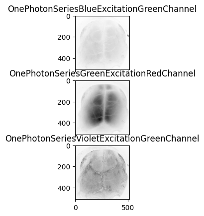

```python
# Visualize the imaging data.
from matplotlib import pyplot as plt
fig, axs = plt.subplots(nrows=len(photon_series_names), ncols=1, sharex=True, sharey=True)
for ps_index,ps_name in enumerate(photon_series_names):
    photon_series = nwbfile.acquisition[ps_name]
    axs[ps_index].imshow(photon_series.data[70], cmap="binary")
    axs[ps_index].set_title(ps_name.replace("_"," "))
plt.show()
```

Imaging metadata include information on the **device** used to acquire the image and the **optical channel** specs contained in the imaging plane object

```python
nwbfile.devices["OnePhotonMicroscope"]
```

OnePhotonMicroscope (Device)

description: Camera Type: DUAL_DCAM, Camera Name: C13440-20C S/N: 301751 S/N: 300073

manufacturer: Hamamatsu Inc.

```python
imaging_planes_names = [imaging_planes_name for imaging_planes_name in nwbfile.imaging_planes.keys()]
print(imaging_planes_names)
nwbfile.imaging_planes[imaging_planes_names[0]]
```

```
['ImagingPlaneBlueExcitationGreenChannel', 'ImagingPlaneGreenExcitationRedChannel', 'ImagingPlaneVioletExcitationGreenChannel']
```

ImagingPlaneBlueExcitationGreenChannel (ImagingPlane)

**optical_channel**

**0 (OpticalChannel)**

description: Green channel of the microscope, 525/50 nm filter.

emission_lambda: 525.0

description: Imaging plane for the Green channel recorded during Blue excitation.

**device (Device)**

description: Camera Type: DUAL_DCAM, Camera Name: C13440-20C S/N: 301751 S/N: 300073

manufacturer: Hamamatsu Inc.

excitation_lambda: 470.0

indicator: ACh3.0

location: Neocortex

conversion: 1.0

unit: meters

origin_coords_unit: meters

grid_spacing_unit: meters

## Accessing the segmentation data

In NWB, the PlaneSegmentation class stores the detected regions of interest in the OnePhotonSeries data. The ImageSegmentation can contain multiple `PlaneSegmentation` tables, so that we can store results of different segmentation algorithms or different segmentation classes.

```python
nwbfile.processing["ophys"]
```

ophys (ProcessingModule)

description: No description.

**DFFOnePhotonSeriesBlue (OnePhotonSeries)**

starting_time: 10.0512

rate: 10.000000000000036

resolution: -1.0

comments: no comments

description: Processed Imaging data from Green channel recorded with Blue excitation. Raw images are detrended and baseline corrected to calculate DF/F images. Specifically, for each pixel, a 100th-order fir filter with 0.001-Hz frequency cutoff was applied to extract the low-pass-filtered signal. This low-pass signal was used as baseline (F0), and DF/F for each pixel was calculated as (F âˆ’ F0)/F0, where F is the raw unfiltered signal.

conversion: 1.0

offset: 0.0

unit: n.a.

**data**

HDF5 dataset

| Data type | float64 |
| --- | --- |
| Shape | (20534, 256, 256) |
| Array size | 10.03 GiB |
| Chunk shape | (19, 256, 256) |
| Compression | gzip |
| Compression opts | 4 |
| Uncompressed size (bytes) | 10765729792 |
| Compressed size (bytes) | 4050949167 |
| Compression ratio | 2.657582050078586 |

starting_time_unit: seconds

**dimension**

HDF5 dataset

| Data type | int32 |
| --- | --- |
| Shape | (2,) |
| Array size | 8.00 bytes |
| Chunk shape | None |
| Compression | None |
| Compression opts | None |
| Uncompressed size (bytes) | 8 |
| Compressed size (bytes) | 8 |
| Compression ratio | 1.0 |

[256 256]

**imaging_plane (ImagingPlane)**

**optical_channel**

**0 (OpticalChannel)**

description: Green channel of the microscope, 525/50 nm filter.

emission_lambda: 525.0

description: Imaging plane for the Green channel recorded during Blue excitation.

**device (Device)**

description: Camera Type: DUAL_DCAM, Camera Name: C13440-20C S/N: 301751 S/N: 300073

manufacturer: Hamamatsu Inc.

excitation_lambda: 470.0

indicator: ACh3.0

location: Neocortex

conversion: 1.0

unit: meters

origin_coords_unit: meters

grid_spacing_unit: meters

**DFFOnePhotonSeriesGreen (OnePhotonSeries)**

starting_time: 10.11516

rate: 10.000000000000036

resolution: -1.0

comments: no comments

description: Processed Imaging data from Red channel recorded with Green excitation. Raw images are detrended and baseline corrected to calculate DF/F images. Specifically, for each pixel, a 100th-order fir filter with 0.001-Hz frequency cutoff was applied to extract the low-pass-filtered signal. This low-pass signal was used as baseline (F0), and DF/F for each pixel was calculated as (F âˆ’ F0)/F0, where F is the raw unfiltered signal.

conversion: 1.0

offset: 0.0

unit: n.a.

**data**

HDF5 dataset

| Data type | float64 |
| --- | --- |
| Shape | (20534, 256, 256) |
| Array size | 10.03 GiB |
| Chunk shape | (19, 256, 256) |
| Compression | gzip |
| Compression opts | 4 |
| Uncompressed size (bytes) | 10765729792 |
| Compressed size (bytes) | 4046531677 |
| Compression ratio | 2.660483261058134 |

starting_time_unit: seconds

**dimension**

HDF5 dataset

| Data type | int32 |
| --- | --- |
| Shape | (2,) |
| Array size | 8.00 bytes |
| Chunk shape | None |
| Compression | None |
| Compression opts | None |
| Uncompressed size (bytes) | 8 |
| Compressed size (bytes) | 8 |
| Compression ratio | 1.0 |

[256 256]

**imaging_plane (ImagingPlane)**

**optical_channel**

**0 (OpticalChannel)**

description: Red channel of the microscope, 630/75 nm filter.

emission_lambda: 630.0

description: Imaging plane for the Red channel recorded during Green excitation.

**device (Device)**

description: Camera Type: DUAL_DCAM, Camera Name: C13440-20C S/N: 301751 S/N: 300073

manufacturer: Hamamatsu Inc.

excitation_lambda: 575.0

indicator: jRCaMP1b

location: Neocortex

conversion: 1.0

unit: meters

origin_coords_unit: meters

grid_spacing_unit: meters

**DFFOnePhotonSeriesViolet (OnePhotonSeries)**

starting_time: 10.083219999999999

rate: 10.000000000000036

resolution: -1.0

comments: no comments

description: Processed Imaging data from Green channel recorded with Violet excitation. Raw images are detrended and baseline corrected to calculate DF/F images. Specifically, for each pixel, a 100th-order fir filter with 0.001-Hz frequency cutoff was applied to extract the low-pass-filtered signal. This low-pass signal was used as baseline (F0), and DF/F for each pixel was calculated as (F âˆ’ F0)/F0, where F is the raw unfiltered signal.

conversion: 1.0

offset: 0.0

unit: n.a.

**data**

HDF5 dataset

| Data type | float64 |
| --- | --- |
| Shape | (20534, 256, 256) |
| Array size | 10.03 GiB |
| Chunk shape | (19, 256, 256) |
| Compression | gzip |
| Compression opts | 4 |
| Uncompressed size (bytes) | 10765729792 |
| Compressed size (bytes) | 9190122192 |
| Compression ratio | 1.1714457726548584 |

starting_time_unit: seconds

**dimension**

HDF5 dataset

| Data type | int32 |
| --- | --- |
| Shape | (2,) |
| Array size | 8.00 bytes |
| Chunk shape | None |
| Compression | None |
| Compression opts | None |
| Uncompressed size (bytes) | 8 |
| Compressed size (bytes) | 8 |
| Compression ratio | 1.0 |

[256 256]

**imaging_plane (ImagingPlane)**

**optical_channel**

**0 (OpticalChannel)**

description: Green channel of the microscope, 525/50 nm filter.

emission_lambda: 525.0

description: Imaging plane for the Green channel recorded during Violet excitation.

**device (Device)**

description: Camera Type: DUAL_DCAM, Camera Name: C13440-20C S/N: 301751 S/N: 300073

manufacturer: Hamamatsu Inc.

excitation_lambda: 395.0

indicator: ACh3.0

location: Neocortex

conversion: 1.0

unit: meters

origin_coords_unit: meters

grid_spacing_unit: meters

**Fluorescence (Fluorescence)**

**RoiResponseSeriesParcellated (RoiResponseSeries)**

starting_time: 10.11516

rate: 10.000000000000036

resolution: -1.0

comments: no comments

description: Fluorescence traces extracted from parcellation algorithm

conversion: 1.0

offset: 0.0

unit: n.a.

**data**

HDF5 dataset

| Data type | float64 |
| --- | --- |
| Shape | (20234, 90) |
| Array size | 13.89 MiB |
| Chunk shape | (16576, 74) |
| Compression | gzip |
| Compression opts | 4 |
| Uncompressed size (bytes) | 14568480 |
| Compressed size (bytes) | 14031361 |
| Compression ratio | 1.0382798931621815 |

starting_time_unit: seconds

**rois (DynamicTableRegion)**

description: The ROIs for ImagingPlaneBlueExcitationGreenChannel.

**table (PlaneSegmentation)**

description: Segmented ROIs

**imaging_plane (ImagingPlane)**

**optical_channel**

**0 (OpticalChannel)**

description: Green channel of the microscope, 525/50 nm filter.

emission_lambda: 525.0

description: Imaging plane for the Green channel recorded during Blue excitation.

**device (Device)**

description: Camera Type: DUAL_DCAM, Camera Name: C13440-20C S/N: 301751 S/N: 300073

manufacturer: Hamamatsu Inc.

excitation_lambda: 470.0

indicator: ACh3.0

location: Neocortex

conversion: 1.0

unit: meters

origin_coords_unit: meters

grid_spacing_unit: meters

**columns**

**image_mask**

Image masks for each ROI.

**ROICentroids**

The x, y, (z) centroids of each ROI.

**table**

| id | image_mask | ROICentroids |
| --- | --- | --- |
| 0 | [[0.0, 0.0, 0.0, 0.0, 0.0, 0.0, 0.0, 0.0, 0.0, 0.0, 0.0, 0.0, 0.0, 0.0, 0.0, 0.0, 0.0, 0.0, 0.0, 0.0, 0.0, 0.0, 0.0, 0.0, 0.0, 0.0, 0.0, 0.0, 0.0, 0.0, 0.0, 0.0, 0.0, 0.0, 0.0, 0.0, 0.0, 0.0, 0.0, 0.0… | [157, 140] |
| 1 | [[0.0, 0.0, 0.0, 0.0, 0.0, 0.0, 0.0, 0.0, 0.0, 0.0, 0.0, 0.0, 0.0, 0.0, 0.0, 0.0, 0.0, 0.0, 0.0, 0.0, 0.0, 0.0, 0.0, 0.0, 0.0, 0.0, 0.0, 0.0, 0.0, 0.0, 0.0, 0.0, 0.0, 0.0, 0.0, 0.0, 0.0, 0.0, 0.0, 0.0… | [169, 130] |
| 2 | [[0.0, 0.0, 0.0, 0.0, 0.0, 0.0, 0.0, 0.0, 0.0, 0.0, 0.0, 0.0, 0.0, 0.0, 0.0, 0.0, 0.0, 0.0, 0.0, 0.0, 0.0, 0.0, 0.0, 0.0, 0.0, 0.0, 0.0, 0.0, 0.0, 0.0, 0.0, 0.0, 0.0, 0.0, 0.0, 0.0, 0.0, 0.0, 0.0, 0.0… | [151, 119] |
| 3 | [[0.0, 0.0, 0.0, 0.0, 0.0, 0.0, 0.0, 0.0, 0.0, 0.0, 0.0, 0.0, 0.0, 0.0, 0.0, 0.0, 0.0, 0.0, 0.0, 0.0, 0.0, 0.0, 0.0, 0.0, 0.0, 0.0, 0.0, 0.0, 0.0, 0.0, 0.0, 0.0, 0.0, 0.0, 0.0, 0.0, 0.0, 0.0, 0.0, 0.0… | [168, 152] |

... and 86 more row(s).

**ImageSegmentation (ImageSegmentation)**

**ParcellatedPlaneSegmentation (PlaneSegmentation)**

description: Segmented ROIs

**imaging_plane (ImagingPlane)**

**optical_channel**

**0 (OpticalChannel)**

description: Green channel of the microscope, 525/50 nm filter.

emission_lambda: 525.0

description: Imaging plane for the Green channel recorded during Blue excitation.

**device (Device)**

description: Camera Type: DUAL_DCAM, Camera Name: C13440-20C S/N: 301751 S/N: 300073

manufacturer: Hamamatsu Inc.

excitation_lambda: 470.0

indicator: ACh3.0

location: Neocortex

conversion: 1.0

unit: meters

origin_coords_unit: meters

grid_spacing_unit: meters

**columns**

**image_mask**

Image masks for each ROI.

**ROICentroids**

The x, y, (z) centroids of each ROI.

**table**

| id | image_mask | ROICentroids |
| --- | --- | --- |
| 0 | [[0.0, 0.0, 0.0, 0.0, 0.0, 0.0, 0.0, 0.0, 0.0, 0.0, 0.0, 0.0, 0.0, 0.0, 0.0, 0.0, 0.0, 0.0, 0.0, 0.0, 0.0, 0.0, 0.0, 0.0, 0.0, 0.0, 0.0, 0.0, 0.0, 0.0, 0.0, 0.0, 0.0, 0.0, 0.0, 0.0, 0.0, 0.0, 0.0, 0.0… | [157, 140] |
| 1 | [[0.0, 0.0, 0.0, 0.0, 0.0, 0.0, 0.0, 0.0, 0.0, 0.0, 0.0, 0.0, 0.0, 0.0, 0.0, 0.0, 0.0, 0.0, 0.0, 0.0, 0.0, 0.0, 0.0, 0.0, 0.0, 0.0, 0.0, 0.0, 0.0, 0.0, 0.0, 0.0, 0.0, 0.0, 0.0, 0.0, 0.0, 0.0, 0.0, 0.0… | [169, 130] |
| 2 | [[0.0, 0.0, 0.0, 0.0, 0.0, 0.0, 0.0, 0.0, 0.0, 0.0, 0.0, 0.0, 0.0, 0.0, 0.0, 0.0, 0.0, 0.0, 0.0, 0.0, 0.0, 0.0, 0.0, 0.0, 0.0, 0.0, 0.0, 0.0, 0.0, 0.0, 0.0, 0.0, 0.0, 0.0, 0.0, 0.0, 0.0, 0.0, 0.0, 0.0… | [151, 119] |
| 3 | [[0.0, 0.0, 0.0, 0.0, 0.0, 0.0, 0.0, 0.0, 0.0, 0.0, 0.0, 0.0, 0.0, 0.0, 0.0, 0.0, 0.0, 0.0, 0.0, 0.0, 0.0, 0.0, 0.0, 0.0, 0.0, 0.0, 0.0, 0.0, 0.0, 0.0, 0.0, 0.0, 0.0, 0.0, 0.0, 0.0, 0.0, 0.0, 0.0, 0.0… | [168, 152] |

... and 86 more row(s).

## Access DF/F one photon series

```python
dff_photon_series_names = [dff_photon_series_name for dff_photon_series_name in nwbfile.processing["ophys"].data_interfaces if "DFFOnePhotonSeries" in dff_photon_series_name]
print(dff_photon_series_names)
```

```
['DFFOnePhotonSeriesBlue', 'DFFOnePhotonSeriesGreen', 'DFFOnePhotonSeriesViolet']
```

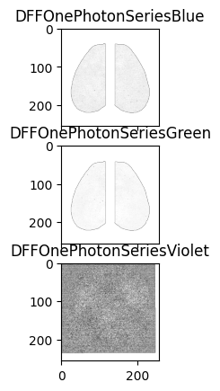

```python
import numpy as np
fig, axs = plt.subplots(nrows=len(dff_photon_series_names), ncols=1, sharex=True, sharey=True)
for ps_index,ps_name in enumerate(dff_photon_series_names):
    dff_photon_series = nwbfile.processing["ophys"][ps_name]
    data = dff_photon_series.data[70]
    data[data == 0] = np.nan
    axs[ps_index].imshow(data, vmin=-0.01, cmap="binary")
    axs[ps_index].set_title(ps_name.replace("_"," "))
plt.show()
```

#### Plot Image Segmentation: Functional Parcellation

```python
plane_segmentation_names = list(nwbfile.processing["ophys"]["ImageSegmentation"].plane_segmentations.keys())
_ = [print(name) for name in nwbfile.processing["ophys"]["ImageSegmentation"].plane_segmentations.keys()]
```

```
ParcellatedPlaneSegmentation
```

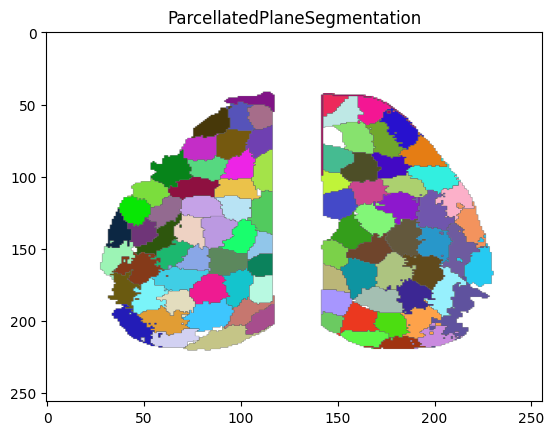

```python
import numpy as np
from matplotlib.colors import ListedColormap
import random

photon_series = nwbfile.acquisition["OnePhotonSeriesBlueExcitationGreenChannel"]
plane_seg_name = plane_segmentation_names[0]
fig, ax = plt.subplots(nrows=1, ncols=1, sharex=True, sharey=True)
plane_segmentation = nwbfile.processing["ophys"]["ImageSegmentation"].plane_segmentations[plane_seg_name]
for image_mask in plane_segmentation.image_mask:
    random_color = [random.random() for _ in range(3)] + [1]
    custom_cmap = ListedColormap([[0, 0, 0, 0], random_color])
    ax.imshow(image_mask.T, aspect="auto", cmap=custom_cmap)
ax.set_title(plane_seg_name)
plt.show()
```

## Visualize fluorescence traces

```python
import pandas as pd
import warnings
warnings.simplefilter(action='ignore', category=pd.errors.PerformanceWarning)

fluorescence_traces_names = [name for name in nwbfile.processing["ophys"]["Fluorescence"].roi_response_series.keys()]

fluorescence_traces_name = fluorescence_traces_names[0]
start_index = 0
stop_index = -1

fluorescence_rate = nwbfile.processing["ophys"]["Fluorescence"][fluorescence_traces_name].rate
fluorescence_starting_time = nwbfile.processing["ophys"]["Fluorescence"][fluorescence_traces_name].starting_time
start_time =fluorescence_starting_time + start_index*fluorescence_rate
stop_time = fluorescence_starting_time + stop_index*fluorescence_rate

fluorescence_traces = nwbfile.processing["ophys"]["Fluorescence"][fluorescence_traces_name].data[:, :10]

df = pd.DataFrame(fluorescence_traces)
df["time"] = np.linspace(start_time, stop_time, fluorescence_traces.shape[0])
df.set_index("time", inplace=True)
df.columns.name = 'ROIs'

import plotly.express as px

fig = px.line(df, facet_row="ROIs", facet_row_spacing=0.01)

# hide and lock down axes
fig.update_xaxes(visible=True, fixedrange=False)
fig.update_yaxes(visible=False, fixedrange=False)

# remove facet/subplot labels
fig.update_layout(annotations=[], overwrite=True)

# strip down the rest of the plot
fig.update_layout(
    showlegend=True,
    plot_bgcolor="white",
    margin=dict(t=10, l=10, b=10, r=10)
)

fig.show(config=dict(displayModeBar=True))
```

[interactive chart not shown]

# Access Processed Behavior

This section demonstrates how to access the face motion components, the eye tracking and pupil tracking data.

```python
nwbfile.processing["behavior"]["EyeTracking"]
```

EyeTracking

**eye_center_of_mass (SpatialSeries)**

resolution: -1.0

comments: no comments

description: The position of the eye measured in degrees.

conversion: 1.0

offset: 0.0

unit: degrees

**data**

HDF5 dataset

| Data type | float32 |
| --- | --- |
| Shape | (21533, 2) |
| Array size | 168.23 KiB |
| Chunk shape | (21533, 2) |
| Compression | gzip |
| Compression opts | 4 |
| Uncompressed size (bytes) | 172264 |
| Compressed size (bytes) | 143268 |
| Compression ratio | 1.2023899265711813 |

**timestamps**

HDF5 dataset

| Data type | float64 |
| --- | --- |
| Shape | (21533,) |
| Array size | 168.23 KiB |
| Chunk shape | (21533,) |
| Compression | gzip |
| Compression opts | 4 |
| Uncompressed size (bytes) | 172264 |
| Compressed size (bytes) | 44824 |
| Compression ratio | 3.8431197572728895 |

timestamps_unit: seconds

interval: 1

reference_frame: unknown

```python
nwbfile.processing["behavior"]["PupilTracking"]
```

PupilTracking

**pupil_area (TimeSeries)**

resolution: -1.0

comments: no comments

description: Area of pupil.

conversion: 1.0

offset: 0.0

unit: unknown

**data**

HDF5 dataset

| Data type | float32 |
| --- | --- |
| Shape | (21533, 1) |
| Array size | 84.11 KiB |
| Chunk shape | (21533, 1) |
| Compression | gzip |
| Compression opts | 4 |
| Uncompressed size (bytes) | 86132 |
| Compressed size (bytes) | 73051 |
| Compression ratio | 1.1790666794431288 |

**timestamps**

HDF5 dataset

| Data type | float64 |
| --- | --- |
| Shape | (21533,) |
| Array size | 168.23 KiB |
| Chunk shape | (21533,) |
| Compression | gzip |
| Compression opts | 4 |
| Uncompressed size (bytes) | 172264 |
| Compressed size (bytes) | 44824 |
| Compression ratio | 3.8431197572728895 |

timestamps_unit: seconds

interval: 1

**pupil_area_raw (TimeSeries)**

resolution: -1.0

comments: no comments

description: Raw unprocessed area of pupil.

conversion: 1.0

offset: 0.0

unit: unknown

**data**

HDF5 dataset

| Data type | float32 |
| --- | --- |
| Shape | (21533, 1) |
| Array size | 84.11 KiB |
| Chunk shape | (21533, 1) |
| Compression | gzip |
| Compression opts | 4 |
| Uncompressed size (bytes) | 86132 |
| Compressed size (bytes) | 75349 |
| Compression ratio | 1.1431074068667135 |

**timestamps**

HDF5 dataset

| Data type | float64 |
| --- | --- |
| Shape | (21533,) |
| Array size | 168.23 KiB |
| Chunk shape | (21533,) |
| Compression | gzip |
| Compression opts | 4 |
| Uncompressed size (bytes) | 172264 |
| Compressed size (bytes) | 44824 |
| Compression ratio | 3.8431197572728895 |

timestamps_unit: seconds

interval: 1

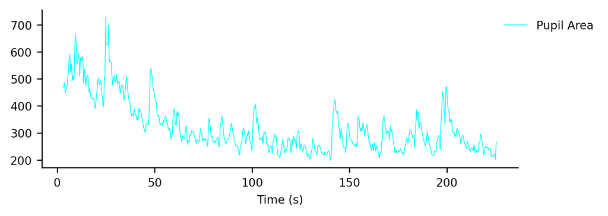

```python
start_index = 0
stop_index = 2000

pupil_area_timestamps = nwbfile.processing["behavior"]["PupilTracking"]["pupil_area"].timestamps[start_index:stop_index]
pupil_area_signal = nwbfile.processing["behavior"]["PupilTracking"]["pupil_area"].data[start_index:stop_index]

fig, ax = plt.subplots(figsize=(6, 2), dpi=300)
ax.plot(pupil_area_timestamps, pupil_area_signal, color="cyan", linewidth=0.5, label="Pupil Area")

# Hide top and right spines
ax.spines['top'].set_visible(False)
ax.spines['right'].set_visible(False)

# Create the
ax.legend(frameon=False, bbox_to_anchor=(.95, 1), loc='upper left', prop={'size': 8})

ax.tick_params(axis='y', labelsize=8)
plt.xlabel('Time (s)', fontsize=8)
plt.tick_params(axis='x', labelsize=8)
plt.show()
```

```python
motion_svd_series = nwbfile.processing["behavior"]["MotionSVDSeriesWhiskers"]
motion_svd_series
```

MotionSVDSeriesWhiskers (MotionSVDSeries)

resolution: -1.0

comments: no comments

description: Motion SVD components for Whiskers components.

conversion: 1.0

offset: 0.0

unit: unknown

**data**

HDF5 dataset

| Data type | float32 |
| --- | --- |
| Shape | (21533, 500) |
| Array size | 41.07 MiB |
| Chunk shape | (10363, 241) |
| Compression | gzip |
| Compression opts | 4 |
| Uncompressed size (bytes) | 43066000 |
| Compressed size (bytes) | 40287736 |
| Compression ratio | 1.0689605392569093 |

**timestamps**

HDF5 dataset

| Data type | float64 |
| --- | --- |
| Shape | (21533,) |
| Array size | 168.23 KiB |
| Chunk shape | (21533,) |
| Compression | gzip |
| Compression opts | 4 |
| Uncompressed size (bytes) | 172264 |
| Compressed size (bytes) | 44824 |
| Compression ratio | 3.8431197572728895 |

timestamps_unit: seconds

interval: 1

**motion_masks (DynamicTableRegion)**

description: all the ROIs motion mask

**table (MotionSVDMasks)**

description: Motion masks for Whiskers components.

downsampling_factor: 4.0

**mask_coordinates**

HDF5 dataset

| Data type | int32 |
| --- | --- |
| Shape | (4,) |
| Array size | 16.00 bytes |
| Chunk shape | None |
| Compression | None |
| Compression opts | None |
| Uncompressed size (bytes) | 16 |
| Compressed size (bytes) | 16 |
| Compression ratio | 1.0 |

[158 166 256 313]

**processed_frame_dimension**

HDF5 dataset

| Data type | int32 |
| --- | --- |
| Shape | (2,) |
| Array size | 8.00 bytes |
| Chunk shape | None |
| Compression | None |
| Compression opts | None |
| Uncompressed size (bytes) | 8 |
| Compressed size (bytes) | 8 |
| Compression ratio | 1.0 |

[275 340]

**columns**

**image_mask**

Motion SVD mask.

**table**

| id | image_mask |
| --- | --- |
| 0 | [[0.0004785988, 0.00048188193, 0.0005026834, 0.0004934805, 0.000494993, 0.0005442115, 0.0005256306, 0.0005147321, 0.00056742306, 0.00072934525, 0.0007626941, 0.0006095713, 0.00045714006, 0.0003683765,… |
| 1 | [[0.00030474304, 0.00032006236, 0.0003800302, 0.00036290725, 0.0003435829, 0.00035854295, 0.00032418058, 0.00031759296, 0.0002983781, 0.00033364203, 0.0002588454, 0.00020788753, 0.00029915638, 0.00029… |
| 2 | [[-6.741994e-05, -0.00014111958, -0.00015840368, -0.000117921474, -0.00017921237, -0.0001861539, -0.00020309979, -0.00017506428, -6.55964e-05, -7.755892e-05, -3.617793e-05, 6.931395e-05, 6.54612e-05, … |
| 3 | [[0.00034524396, 0.00027307298, 0.00013707878, 0.00022420991, 0.0001805028, 0.00016323259, -1.4521481e-05, 0.00014827936, 0.0002497992, 0.00033502452, 0.00034793743, 0.00032236194, 0.00038709168, 0.00… |

... and 496 more row(s).

```python
motion_svd_masks = nwbfile.processing["behavior"]["MotionSVDMasksWhiskers"]
motion_svd_masks
```

MotionSVDMasksWhiskers (MotionSVDMasks)

description: Motion masks for Whiskers components.

downsampling_factor: 4.0

**mask_coordinates**

HDF5 dataset

| Data type | int32 |
| --- | --- |
| Shape | (4,) |
| Array size | 16.00 bytes |
| Chunk shape | None |
| Compression | None |
| Compression opts | None |
| Uncompressed size (bytes) | 16 |
| Compressed size (bytes) | 16 |
| Compression ratio | 1.0 |

[158 166 256 313]

**processed_frame_dimension**

HDF5 dataset

| Data type | int32 |
| --- | --- |
| Shape | (2,) |
| Array size | 8.00 bytes |
| Chunk shape | None |
| Compression | None |
| Compression opts | None |
| Uncompressed size (bytes) | 8 |
| Compressed size (bytes) | 8 |
| Compression ratio | 1.0 |

[275 340]

**columns**

**image_mask**

Motion SVD mask.

**table**

| id | image_mask |
| --- | --- |
| 0 | [[0.0004785988, 0.00048188193, 0.0005026834, 0.0004934805, 0.000494993, 0.0005442115, 0.0005256306, 0.0005147321, 0.00056742306, 0.00072934525, 0.0007626941, 0.0006095713, 0.00045714006, 0.0003683765,… |
| 1 | [[0.00030474304, 0.00032006236, 0.0003800302, 0.00036290725, 0.0003435829, 0.00035854295, 0.00032418058, 0.00031759296, 0.0002983781, 0.00033364203, 0.0002588454, 0.00020788753, 0.00029915638, 0.00029… |
| 2 | [[-6.741994e-05, -0.00014111958, -0.00015840368, -0.000117921474, -0.00017921237, -0.0001861539, -0.00020309979, -0.00017506428, -6.55964e-05, -7.755892e-05, -3.617793e-05, 6.931395e-05, 6.54612e-05, … |
| 3 | [[0.00034524396, 0.00027307298, 0.00013707878, 0.00022420991, 0.0001805028, 0.00016323259, -1.4521481e-05, 0.00014827936, 0.0002497992, 0.00033502452, 0.00034793743, 0.00032236194, 0.00038709168, 0.00… |

... and 496 more row(s).

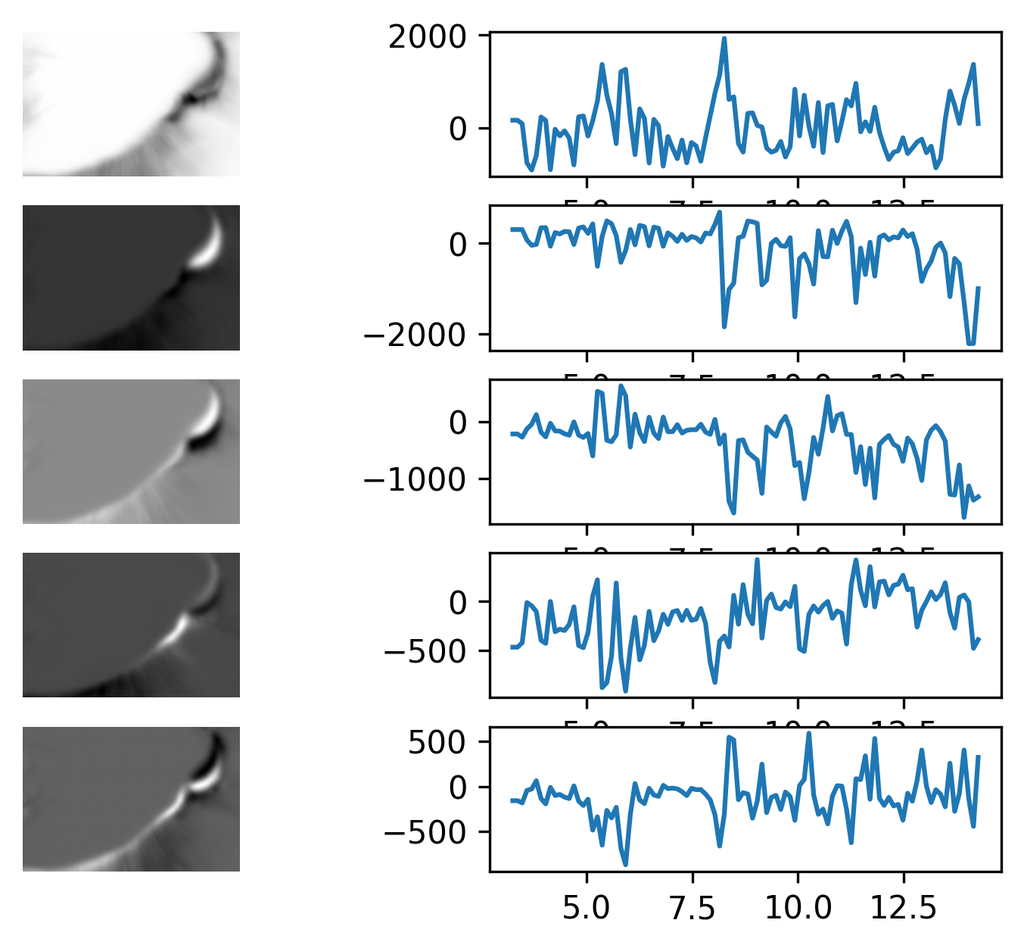

```python
n_components_to_visualize = 5
start_index = 0
stop_index = 100
fig, ax = plt.subplots(nrows=n_components_to_visualize, ncols=2, dpi=300)
for i in range(n_components_to_visualize):
    mask =np.array(motion_svd_masks[i].image_mask[i])
    ax[i, 0].imshow(mask, cmap="binary")
    ax[i, 0].set_axis_off()
    series = motion_svd_series.data[start_index:stop_index,i]
    timestamps = motion_svd_series.timestamps[start_index:stop_index]
    ax[i,1].plot(timestamps, series)
```

# Access Visual Stimulus, Wheel Activation or Airpuff tables

This section demonstrates how to access the visual stimulus or wheel activation or airpuff data.

```python
table_object_type = "VisualStimulus" # "VisualStimulus" "Airpuff" "WheelActivation"
table_object = nwbfile.intervals[table_object_type].to_dataframe()
table_object
```

| id | start_time | stop_time | contrast | orientation | stimulus_frequency | spatial_frequency | stimulus_size | screen_coordinates |
| --- | --- | --- | --- | --- | --- | --- | --- | --- |
| 0 | 34.1448 | 36.1544 | 5 | 0 | 2 | 0.04 | 2 | [20.0, 667.97, 317.97, 932.03] |
| 1 | 41.1948 | 43.1876 | 20 | 0 | 2 | 0.04 | 2 | [20.0, 667.97, 317.97, 932.03] |
| 2 | 48.2280 | 50.2210 | 50 | 0 | 2 | 0.04 | 2 | [20.0, 667.97, 317.97, 932.03] |
| 3 | 55.2612 | 57.2542 | 20 | 0 | 2 | 0.04 | 2 | [20.0, 667.97, 317.97, 932.03] |
| 4 | 62.2944 | 64.2874 | 100 | 0 | 2 | 0.04 | 2 | [20.0, 667.97, 317.97, 932.03] |
| ... | ... | ... | ... | ... | ... | ... | ... | ... |
| 294 | 2102.1360 | 2104.1330 | 5 | 0 | 2 | 0.04 | 2 | [20.0, 667.97, 317.97, 932.03] |
| 295 | 2109.1692 | 2111.1662 | 20 | 0 | 2 | 0.04 | 2 | [20.0, 667.97, 317.97, 932.03] |
| 296 | 2116.2024 | 2118.1994 | 100 | 0 | 2 | 0.04 | 2 | [20.0, 667.97, 317.97, 932.03] |
| 297 | 2123.2358 | 2125.2326 | 100 | 0 | 2 | 0.04 | 2 | [20.0, 667.97, 317.97, 932.03] |
| 298 | 2130.2690 | 2132.2660 | 50 | 0 | 2 | 0.04 | 2 | [20.0, 667.97, 317.97, 932.03] |

299 rows × 8 columns

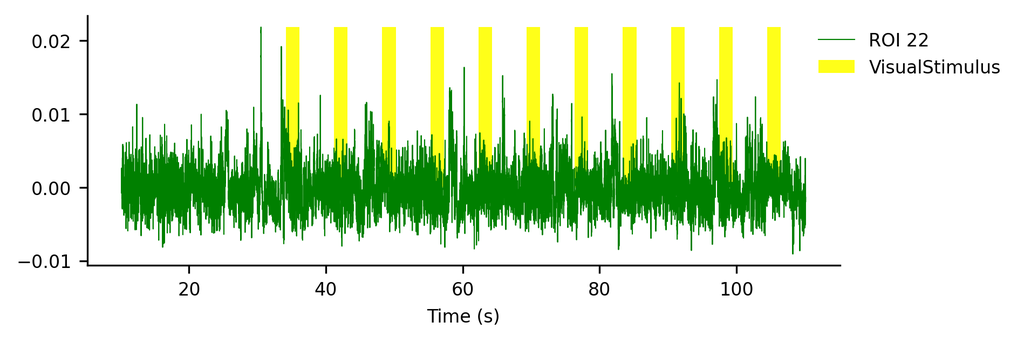

```python
start_index = 0
stop_index = 1000

fluorescence_rate = nwbfile.processing["ophys"]["Fluorescence"][fluorescence_traces_name].rate
fluorescence_starting_time = nwbfile.processing["ophys"]["Fluorescence"][fluorescence_traces_name].starting_time
start_time =fluorescence_starting_time + start_index/fluorescence_rate
stop_time = fluorescence_starting_time + stop_index/fluorescence_rate

ROI_index=22
fluorescence_data = nwbfile.processing["ophys"]["Fluorescence"][fluorescence_traces_name].data[:, ROI_index]
fluorescence_timestamps = np.linspace(start_time, stop_time, fluorescence_data.shape[0])

fig, ax = plt.subplots(figsize=(6, 2), dpi=300)
line_handle, = ax.plot(fluorescence_timestamps, fluorescence_data, color="green", linewidth=0.5, label=f"ROI {ROI_index}".format(ROI_index=ROI_index))

handles = []
for (stimulus_start, stimulus_stop) in zip(table_object["start_time"], table_object["stop_time"]):
    handle = ax.fill_between(fluorescence_timestamps, np.nanmax(fluorescence_data), where=(fluorescence_timestamps >= stimulus_start) & (fluorescence_timestamps <= stimulus_stop),color='yellow', edgecolor='none', alpha=0.9, label=table_object_type)
    handles.append(handle)

# Hide top and right spines
ax.spines['top'].set_visible(False)
ax.spines['right'].set_visible(False)

# Create the legend with the appropriate handles
handles = [line_handle, handles[0]]
labels = [f"ROI {ROI_index}".format(ROI_index=ROI_index), table_object_type]
ax.legend(handles, labels, frameon=False, bbox_to_anchor=(.95, 1), loc='upper left', prop={'size': 8})

ax.tick_params(axis='y', labelsize=8)
plt.xlabel('Time (s)', fontsize=8)
plt.tick_params(axis='x', labelsize=8)
plt.show()
```

# Access Wheel Signal and Wheel Speed

This section demonstrates how to access the raw wheel signal acquired with Spike2 and the processed wheel speed trace.

```python
nwbfile.acquisition["WheelSignal"]
```

WheelSignal (TimeSeries)

starting_time: 0.0

rate: 5000.0

resolution: -1.0

comments: no comments

description: The WheelSignal measured over time.

conversion: 0.000152587890625

offset: 0.0

unit: Volts

**data**

HDF5 dataset

| Data type | int16 |
| --- | --- |
| Shape | (10816511,) |
| Array size | 20.63 MiB |
| Chunk shape | (5000000,) |
| Compression | gzip |
| Compression opts | 4 |
| Uncompressed size (bytes) | 21633022 |
| Compressed size (bytes) | 14302692 |
| Compression ratio | 1.5125140078525077 |

starting_time_unit: seconds

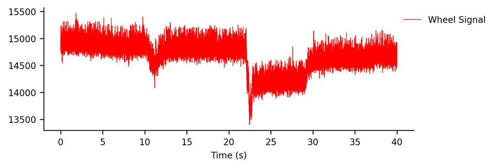

```python
start_index = 0
stop_index = 200000

wheel_signal_rate = nwbfile.acquisition["WheelSignal"].rate
wheel_signal_starting_time = nwbfile.acquisition["WheelSignal"].starting_time
start_time = wheel_signal_starting_time + start_index/wheel_signal_rate
stop_time = wheel_signal_starting_time + stop_index/wheel_signal_rate

wheel_signal = nwbfile.acquisition["WheelSignal"].data[start_index:stop_index]
wheel_signal_timestamps = np.linspace(start_time, stop_time, wheel_signal.shape[0])

fig, ax = plt.subplots(figsize=(6, 2), dpi=300)
ax.plot(wheel_signal_timestamps, wheel_signal, color="red", linewidth=0.5, label="Wheel Signal")

# Hide top and right spines
ax.spines['top'].set_visible(False)
ax.spines['right'].set_visible(False)

# Create the
ax.legend(frameon=False, bbox_to_anchor=(.95, 1), loc='upper left', prop={'size': 8})

ax.tick_params(axis='y', labelsize=8)
plt.xlabel('Time (s)', fontsize=8)
plt.tick_params(axis='x', labelsize=8)
plt.show()
```

```python
nwbfile.processing["behavior"]["WheelSpeed"]
```

WheelSpeed (TimeSeries)

starting_time: 0.0

rate: 5000.0

resolution: -1.0

comments: no comments

description: Wheel speed

conversion: 1.0

offset: 0.0

unit: unknown

**data**

HDF5 dataset

| Data type | float64 |
| --- | --- |
| Shape | (10816512,) |
| Array size | 82.52 MiB |
| Chunk shape | (1250000,) |
| Compression | gzip |
| Compression opts | 4 |
| Uncompressed size (bytes) | 86532096 |
| Compressed size (bytes) | 82415942 |
| Compression ratio | 1.0499436625986753 |

starting_time_unit: seconds

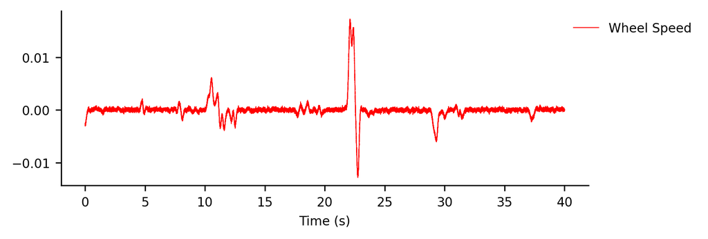

```python
start_index = 0
stop_index = 200000

wheel_speed_rate = nwbfile.processing["behavior"]["WheelSpeed"].rate
wheel_speed_starting_time = nwbfile.processing["behavior"]["WheelSpeed"].starting_time
start_time = wheel_speed_starting_time + start_index/wheel_speed_rate
stop_time = wheel_speed_starting_time + stop_index/wheel_speed_rate

wheel_speed = nwbfile.processing["behavior"]["WheelSpeed"].data[start_index:stop_index]
wheel_speed_timestamps = np.linspace(start_time, stop_time, wheel_speed.shape[0])

fig, ax = plt.subplots(figsize=(6, 2), dpi=300)
ax.plot(wheel_speed_timestamps, wheel_speed, color="red", linewidth=0.5, label="Wheel Speed")

# Hide top and right spines
ax.spines['top'].set_visible(False)
ax.spines['right'].set_visible(False)

# Create the
ax.legend(frameon=False, bbox_to_anchor=(.95, 1), loc='upper left', prop={'size': 8})

ax.tick_params(axis='y', labelsize=8)
plt.xlabel('Time (s)', fontsize=8)
plt.tick_params(axis='x', labelsize=8)
plt.show()
```